# ST558 Porject 1: Part 3

Bridget Knapp and Chien-Lan Hsueh

2022-07-10

## News Channel: `lifestyle`

In this section, a quick EDA will be done on the **training set** for news channel `lifestyle`:

- Overlook of the data set
- Response variable
- Categorical Predictors
- Numeric Predictors

### Overlook of the data set

Verify the data sets only has data from `lifestyle` channel:

```r
table(df_train_x$channel, df_train_x$weekday)
```

[output not shown]

```r
table(df_test_x$channel, df_test_x$weekday)
```

[output not shown]

The tables below give quick summaries of all the numeric and categorical variables:

```r
# quick summaries of numeric and categorical variables
skim(df_train_x)
```

```
-- Data Summary ------------------------
                           Values
Name                       df_train_x
Number of rows             1464
Number of columns          48
_______________________
Column type frequency:
  factor                   3
  numeric                  45
________________________
Group variables            None
```

|  | skim_variable | n_missing | complete_rate | ordered | n_unique | top_counts |
| --- | --- | --- | --- | --- | --- | --- |
| 1 | channel | 0 | 1 | FALSE | 1 | lif: 1464, bus: 0, ent: 0, mis: 0 |
| 2 | weekday | 0 | 1 | FALSE | 7 | wed: 277, thu: 261, tue: 230, mon: 225 |
| 3 | is_weekend | 0 | 1 | FALSE | 2 | N: 1193, Y: 271 |

|  | skim_variable | n_missing | complete_rate | mean | sd | p0 | p25 | p50 | p75 | p100 | hist |
| --- | --- | --- | --- | --- | --- | --- | --- | --- | --- | --- | --- |
| 1 | shares | 0 | 1 | 3.633956e+03 | 8.139577e+03 | 28.00000000 | 1.100000e+03 | 1.700000e+03 | 3.200000e+03 | 2.083000e+05 |  |
| 2 | n_tokens_title | 0 | 1 | 9.754781e+00 | 1.936618e+00 | 3.00000000 | 8.000000e+00 | 1.000000e+01 | 1.100000e+01 | 1.800000e+01 |  |
| 3 | n_tokens_content | 0 | 1 | 6.216605e+02 | 5.916999e+02 | 0.00000000 | 2.990000e+02 | 4.980000e+02 | 7.995000e+02 | 8.474000e+03 |  |
| 4 | n_unique_tokens | 0 | 1 | 5.262753e-01 | 1.073895e-01 | 0.00000000 | 4.634146e-01 | 5.221399e-01 | 5.929198e-01 | 8.681319e-01 |  |
| 5 | n_non_stop_words | 0 | 1 | 9.911202e-01 | 9.384533e-02 | 0.00000000 | 1.000000e+00 | 1.000000e+00 | 1.000000e+00 | 1.000000e+00 |  |
| 6 | n_non_stop_unique_tokens | 0 | 1 | 6.857902e-01 | 1.145848e-01 | 0.00000000 | 6.273795e-01 | 6.843861e-01 | 7.543506e-01 | 1.000000e+00 |  |
| 7 | num_hrefs | 0 | 1 | 1.332650e+01 | 1.189772e+01 | 0.00000000 | 6.000000e+00 | 1.000000e+01 | 1.800000e+01 | 1.450000e+02 |  |
| 8 | num_self_hrefs | 0 | 1 | 2.510246e+00 | 2.883456e+00 | 0.00000000 | 1.000000e+00 | 2.000000e+00 | 3.000000e+00 | 4.000000e+01 |  |
| 9 | num_imgs | 0 | 1 | 4.843579e+00 | 8.308524e+00 | 0.00000000 | 1.000000e+00 | 1.000000e+00 | 8.000000e+00 | 1.110000e+02 |  |
| 10 | num_videos | 0 | 1 | 4.562842e-01 | 1.889859e+00 | 0.00000000 | 0.000000e+00 | 0.000000e+00 | 0.000000e+00 | 5.000000e+01 |  |

[output cut: 35 more lines]

### Response Variable

Next, let’s learn more about our response variable: `shares` with a 5-number summary. With a histogram, we can visually see it’s distribution and determine if it is symmetric, skewed left, or skewed right.

```r
# 5-number summary on shares
summary(df_train_x$shares)
```

[output not shown]

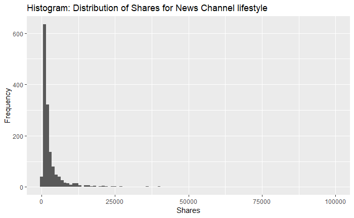

```r
# histogram on shares
df_train_x %>%
  ggplot(aes(x = shares)) +
  geom_histogram(binwidth = 1000) +
  coord_cartesian(xlim = c(0, 100000)) +
  labs(
    title = paste0("Histogram: Distribution of Shares for News Channel ", params$channel),
    x="Shares",
    y="Frequency")
```

### Categorical Predictors

Despite the `channel` variable, there are two categorical variables `weekday`, `is_weekend`. A one-way contigency table shows how many articles were published on each weekday.

```r
df_train_x %>%
  select(weekday, is_weekend) %>%
  summary()
```

```
      weekday    is_weekend
 sunday   :149   N:1193
 monday   :225   Y: 271
 tuesday  :230
 wednesday:277
 thursday :261
 friday   :200
 saturday :122
```

The following side-by-side box plots help us visualize the distributions of `shares` on each weekday.

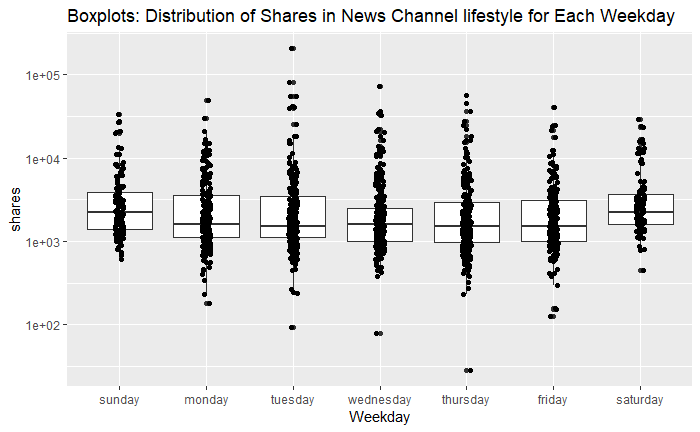

```r
df_train_x %>%
  ggplot(aes(weekday, shares)) +
  geom_boxplot() +
  scale_y_log10() +
  geom_jitter(width = 0.05) +
  labs(
    title = paste0("Boxplots: Distribution of Shares in News Channel ", params$channel, " for Each Weekday"),
    x = "Weekday")
```

### Numeric Predictors

We have 45 numeric variables. To further investigate the relationship among these numeric variables, we check their correlation by making pair-wise correlation plots.

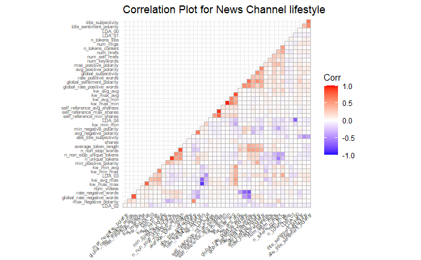

```r
ggcorrplot(
  cor(select_if(df_train_x, is.numeric), use = "complete.obs"),
  hc.order = TRUE,
  type = "lower",
  tl.cex = 6,
  title = paste0("Correlation Plot for News Channel ", params$channel))
```

Below, we use scatter plots to inspect the relationship between the response variable `shares` and various numeric variables in related groups:

- `shares` vs. token-related variables
- `shares` vs. numbers of links, keyword, images, videos
- `shares` vs. keyword-related metrics
- `shares` vs. tone polarity metrics
- `shares` vs. title-related metrics

#### `shares` vs. Token-related Variables

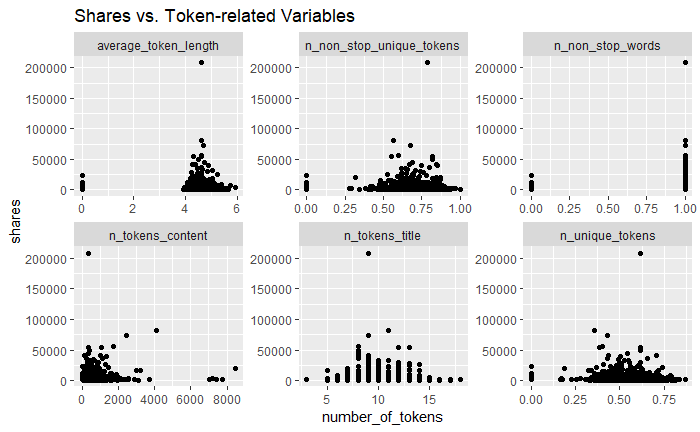

```r
# scatter plots: shares vs. token-related variables
df_train_x %>%
  select(shares, starts_with("n_"), contains("token")) %>%
  pivot_longer(
    cols = -c(shares),
    names_to = "token_metric",
    values_to = "number_of_tokens") %>%
  ggplot(aes(number_of_tokens, shares)) +
  geom_point() +
  facet_wrap(vars(token_metric), scales = "free") +
  ggtitle("Shares vs. Token-related Variables")
```

#### `shares` vs. numbers of links, keywords, images and videos

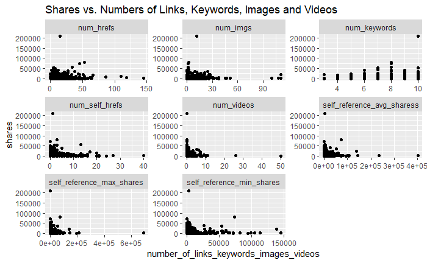

```r
# scatter plots: shares vs. numbers of links, keywords, images and videos
df_train_x %>%
  select(shares, starts_with("num_"), starts_with("self_reference")) %>%
  pivot_longer(
    cols = -c(shares),
    names_to = "number_metric",
    values_to = "number_of_links_keywords_images_videos") %>%
  ggplot(aes(number_of_links_keywords_images_videos, shares)) +
  geom_point() +
  facet_wrap(vars(number_metric), scales = "free") +
  ggtitle("Shares vs. Numbers of Links, Keywords, Images and Videos")
```

#### `shares` vs. Keyword-related Metrics

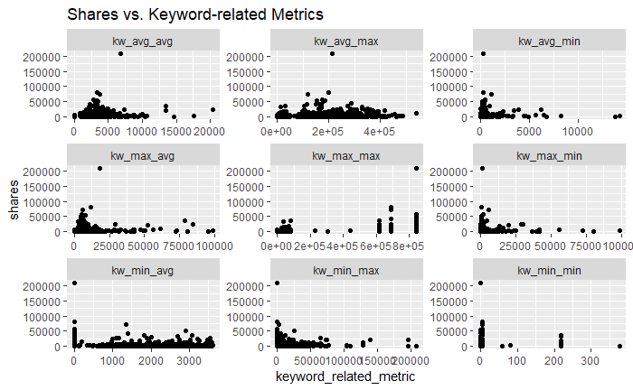

```r
# scatter plots: shares vs. numbers of links, keywords, images and videos
df_train_x %>%
  select(shares, starts_with("kw_")) %>%
  pivot_longer(
    cols = -c(shares),
    names_to = "number_metric",
    values_to = "keyword_related_metric") %>%
  ggplot(aes(keyword_related_metric, shares)) +
  geom_point() +
  facet_wrap(vars(number_metric), scales = "free") +
  ggtitle("Shares vs. Keyword-related Metrics")
```

#### `shares` vs. Word Polarity Metrics

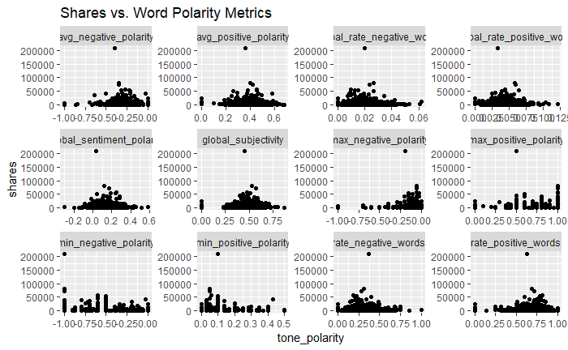

```r
# scatter plots: shares vs. numbers of links, keywords, images and videos
df_train_x %>%
  select(
    shares,
    contains("subjectivity"),
    contains("polarity"),
    contains("positive"),
    contains("negative"),
    -contains("title")) %>%
  pivot_longer(
    cols = -c(shares),
    names_to = "number_metric",
    values_to = "tone_polarity") %>%
  ggplot(aes(tone_polarity, shares)) +
  geom_point() +
  facet_wrap(vars(number_metric), scales = "free") +
  ggtitle("Shares vs. Word Polarity Metrics")
```

#### `shares` vs. Title-related Metrics

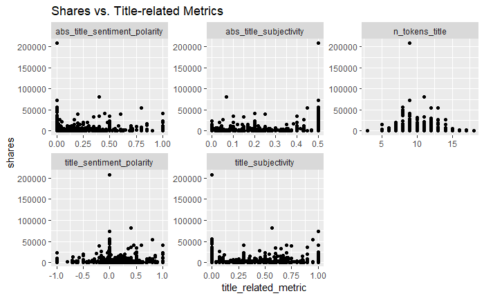

```r
# scatter plots: shares vs. numbers of links, keywords, images and videos
df_train_x %>%
  select(shares, contains("title")) %>%
  pivot_longer(
    cols = -c(shares),
    names_to = "number_metric",
    values_to = "title_related_metric") %>%
  ggplot(aes(title_related_metric, shares)) +
  geom_point() +
  facet_wrap(vars(number_metric), scales = "free") +
  ggtitle("Shares vs. Title-related Metrics")
```